# Predictors of Health Outcomes: A Linear Regression Analysis of Lifestyle and Demographic Factors

Dapo

2026-08-05

## Objectives

This analysis aims to answer the following questions: 1. Which lifestyle and demographic factors are most strongly associated with Health Score 2. Can a linear regression model reliably predict Health Score from these factors.

## Methodology

Data was cleaned and explored descriptively, followed by bivariate visualizations of each predictor against Health Score. A multiple linear regression model was fit using all available predictors, refined via stepwise selection, and evaluated against standard regression assumptions(linearity, homoscedasticity, normality, multicollinearity, and influential points).

Introduction

```r
knitr::opts_chunk$set(echo = TRUE)
library(tidyverse)
library(gtExtras)
dataset <- read_csv("C:/Users/Adedapo/Documents/synthetic_health_data.csv")
dataset %>%
  head(10) %>%
  gt()
```

| Age | BMI | Exercise_Frequency | Diet_Quality | Sleep_Hours | Smoking_Status | Alcohol_Consumption | Health_Score |
| --- | --- | --- | --- | --- | --- | --- | --- |
| 45.96057 | 31.99678 | 5 | 55.40327 | 7.300359 | 0 | 2.8347071 | 70.54212 |
| 38.34083 | 29.62317 | 6 | 41.83836 | 7.012419 | 1 | 7.1995168 | 57.24464 |
| 47.77226 | 25.29815 | 5 | 76.90495 | 6.028641 | 1 | 4.0979438 | 96.33372 |
| 58.27636 | 21.76532 | 2 | 49.75677 | 5.802714 | 1 | 3.6493772 | 61.32178 |
| 37.19016 | 28.49112 | 2 | 44.21874 | 7.912548 | 0 | 2.8397951 | 67.17589 |
| 37.19036 | 26.96743 | 2 | 89.12484 | 7.786489 | 1 | 1.5937579 | 100.00000 |
| 58.95055 | 29.47597 | 5 | 81.52269 | 7.085705 | 0 | 3.6227856 | 91.38567 |
| 49.20922 | 28.17586 | 3 | 65.00243 | 8.386293 | 0 | 0.2353948 | 94.85389 |
| 34.36631 | 30.24776 | 4 | 67.98930 | 4.058009 | 1 | 0.3274318 | 78.35616 |
| 46.51072 | 22.32382 | 4 | 33.88984 | 6.153408 | 0 | 5.0248769 | 64.38028 |

```r
glimpse(dataset)
```

```
## Rows: 1,000
## Columns: 8
## $ Age                 <dbl> 45.96057, 38.34083, 47.77226, 58.27636, 37.19016, …
## $ BMI                 <dbl> 31.99678, 29.62317, 25.29815, 21.76532, 28.49112, …
## $ Exercise_Frequency  <dbl> 5, 6, 5, 2, 2, 2, 5, 3, 4, 4, 1, 4, 4, 2, 2, 5, 1,…
## $ Diet_Quality        <dbl> 55.40327, 41.83836, 76.90495, 49.75677, 44.21874, …
## $ Sleep_Hours         <dbl> 7.300359, 7.012419, 6.028641, 5.802714, 7.912548, …
## $ Smoking_Status      <dbl> 0, 1, 1, 1, 0, 1, 0, 0, 1, 0, 1, 1, 0, 1, 1, 1, 1,…
## $ Alcohol_Consumption <dbl> 2.8347071, 7.1995168, 4.0979438, 3.6493772, 2.8397…
## $ Health_Score        <dbl> 70.54212, 57.24464, 96.33372, 61.32178, 67.17589, …
```

The data set consists of 1000 observations across 8 variables: Age, BMI, Excecise_Frequency, Diet_Quality, Sleep_Hours, Smoking_status, Alcohol_Consumption, and the outcome, Health_Score. Package Tidyverse was loaded for data cleaning, organization and visualization. Package gtExtras was loaded to produce visually apealing tables.

Data Cleaning

```r
library(naniar)
  miss_var_summary(dataset)
```

```
## # A tibble: 8 × 3
##   variable            n_miss pct_miss
##   <chr>                <int>    <num>
## 1 Age                      0        0
## 2 BMI                      0        0
## 3 Exercise_Frequency       0        0
## 4 Diet_Quality             0        0
## 5 Sleep_Hours              0        0
## 6 Smoking_Status           0        0
## 7 Alcohol_Consumption      0        0
## 8 Health_Score             0        0
```

Missing data check with naniar::miss_var summary() confirmed zero missing values across every variable, so no imputation was needed.

```r
dataset_edit <- dataset %>%
  mutate(Alcohol_Consumption = if_else(Alcohol_Consumption <0, 0, Alcohol_Consumption)) %>%
  mutate(Smoking_Status = factor(Smoking_Status, levels = c("0", "1"), labels = c("Non-smoker", "Smoker"))) %>%
  mutate(Exercise_Frequency = factor(Exercise_Frequency, levels = c("0", "1", "2", "3", "4", "5", "6"), labels = c("None", "Once a week", "Twice a week", "Thrice a week", "Four times a week", "Five times a week", "Six times a week")))
```

Alcohol_Consumption contained some invalid negative entries, these were corrected to 0, Since Alcohol Consumption cannot be a negative figure. Smoking_status was converted to a factor, 0 was named Non-smoker, while 1 was Smoker. Exercise Frequency was also converted to a Factor and was named appropriately for frequency of exercise weekly.

```r
summary_table <- dataset_edit %>%
  summarise(
    across(c(Health_Score, Age, Diet_Quality, BMI, Sleep_Hours, Alcohol_Consumption),
           list(Mean = ~mean(.x, na.rm = TRUE),
                Median = ~median(.x, na.rm = TRUE),
                SD = ~sd(.x, na.rm = TRUE),
                Min = ~min(.x, na.rm = TRUE),
                Max = ~max(.x, na.rm = TRUE)))) %>%
  pivot_longer(everything(),
               names_to = c("Variable", "Statistic"),
               names_pattern = "^(.*)_(Mean|Median|SD|Min|Max)$") %>%
  pivot_wider(names_from = Statistic,
              values_from = value)
  summary_table %>%
    gt() %>%
    fmt_number(columns = where(is.numeric),
               decimals = 2)
```

| Variable | Mean | Median | SD | Min | Max |
| --- | --- | --- | --- | --- | --- |
| Health_Score | 85.48 | 87.50 | 13.63 | 29.11 | 100.00 |
| Age | 40.23 | 40.30 | 11.75 | 1.10 | 86.23 |
| Diet_Quality | 69.95 | 69.98 | 14.97 | 19.91 | 110.27 |
| BMI | 25.35 | 25.32 | 4.99 | 10.30 | 40.97 |
| Sleep_Hours | 6.97 | 6.99 | 1.52 | 2.43 | 11.64 |
| Alcohol_Consumption | 3.14 | 3.06 | 1.97 | 0.00 | 11.11 |

Descriptive statistical analysis was performed to summarize the distribution and variability of the numerical variables using the mean, median, standard deviation, minimum, and maximum. The minimum health score is 29.11 while the maximum is 100. Alcohol consumption has a minimum of 0 and a maximum of 11.11. All variables have similar mean and median which suggests that the distributions are generally not strongly skewed.

```r
dataset_edit %>%
    count(Smoking_Status) %>%
    mutate(Percentage = n/sum(n)*100) %>%
  gt()
```

| Smoking_Status | n | Percentage |
| --- | --- | --- |
| Non-smoker | 501 | 50.1 |
| Smoker | 499 | 49.9 |

```r
dataset_edit %>%
    count(Exercise_Frequency) %>%
    mutate(Percentage = n/sum(n)*100) %>%
  gt()
```

| Exercise_Frequency | n | Percentage |
| --- | --- | --- |
| None | 161 | 16.1 |
| Once a week | 139 | 13.9 |
| Twice a week | 147 | 14.7 |
| Thrice a week | 149 | 14.9 |
| Four times a week | 141 | 14.1 |
| Five times a week | 134 | 13.4 |
| Six times a week | 129 | 12.9 |

Descriptive analysis of the categorical variables: Smoking status, 50.1% of the participants are Non-smokers, representing slightly more than half, while 49.9% are smokers Exercise frequency, 16.1% of the participants do not exercise, representing the highest percentage, while the lowest is six times weekly, represented by 12.9% of the population.

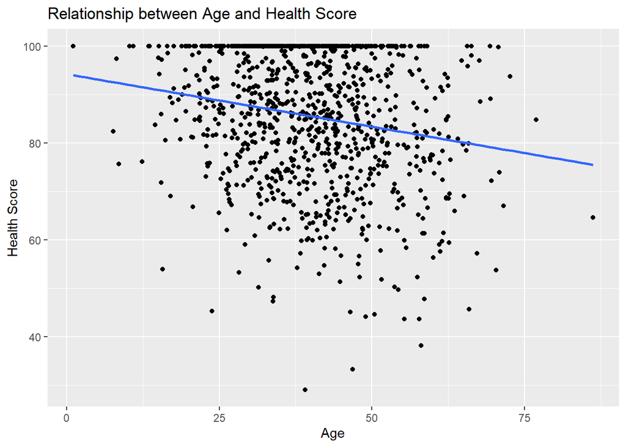

```r
dataset_age <- dataset_edit %>%
  ggplot(aes(Age, Health_Score))+
  geom_point()+
  geom_smooth(method = lm, se = F)+
  labs(title = "Relationship between Age and Health Score", x = "Age", y = "Health Score")
dataset_age
```

There is a negative relationship between Age and Health Score, The older people are, the lesser the Health Score

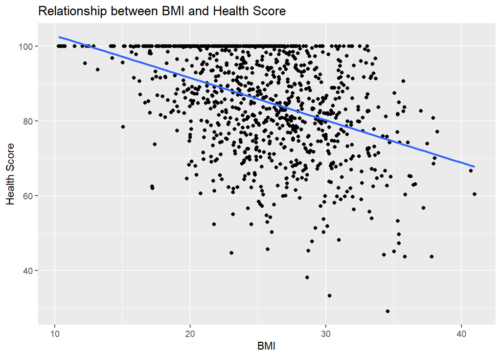

```r
dataset_bmi <- dataset_edit %>%
  ggplot(aes(BMI, Health_Score))+
  geom_point()+
  geom_smooth(method = lm, se = F)+
  labs(title = "Relationship between BMI and Health Score", x = "BMI", y = "Health Score")
dataset_bmi
```

There is a strong negative relationship between BMI and Health Score, the higher the BMI, the lower the Health Score

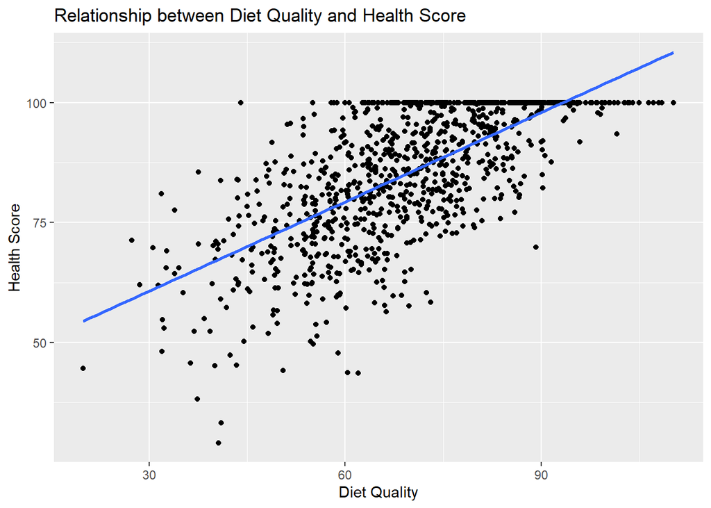

```r
dataset_diet <- dataset %>%
  ggplot(aes(Diet_Quality, Health_Score))+
  geom_point()+
  geom_smooth(method = lm, se = F)+
  labs(title = "Relationship between Diet Quality and Health Score", x = "Diet Quality", y = "Health Score")
dataset_diet
```

There is a strong positive relationship between Diet Quality and Health Score. Hence, people with better diet tend to be healthier

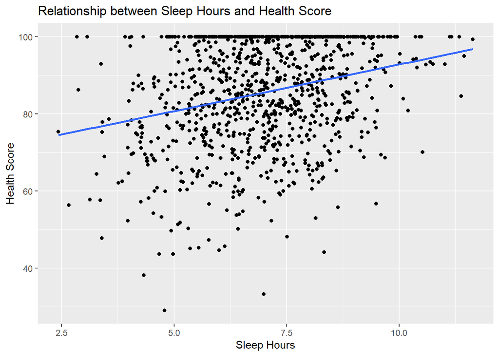

```r
dataset_sleep <- dataset %>%
  ggplot(aes(Sleep_Hours, Health_Score))+
  geom_point()+
  geom_smooth(method = lm, se = F)+
  labs(title = "Relationship between Sleep Hours and Health Score", x = "Sleep Hours", y = "Health Score")
dataset_sleep
```

A positive relationship exists between Sleep Hours and Health Score, More sleep is associated with a higher health score

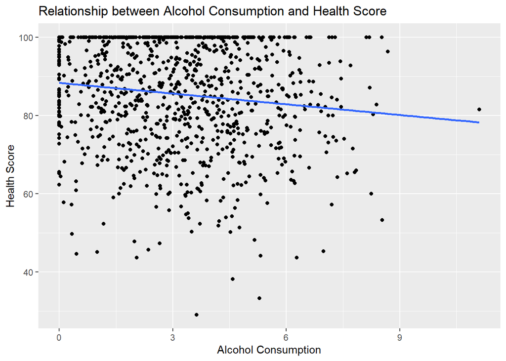

```r
dataset_alcohol <- dataset_edit %>%
  ggplot(aes(Alcohol_Consumption, Health_Score))+
  geom_point()+
  geom_smooth(method = lm, se = F)+
  labs(title = "Relationship between Alcohol Consumption and Health Score", x = "Alcohol Consumption", y = "Health Score")
dataset_alcohol
```

There is a mild negative relationship between Alcohol Consumption and Health Score, Increase in Alcohol intake is associated with a reduction in Health Score.

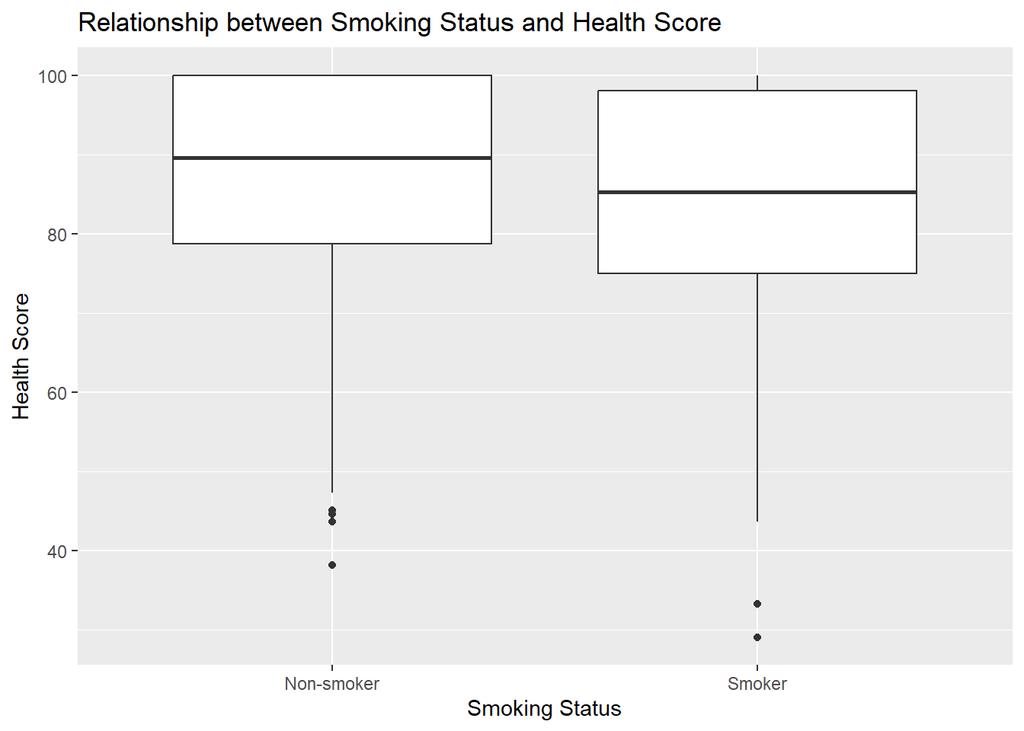

```r
dataset_smoking <- dataset_edit %>%
  mutate(Smoking_Status = factor(Smoking_Status)) %>%
  ggplot(aes(Smoking_Status, Health_Score))+
  geom_boxplot()+
  labs(title = "Relationship between Smoking Status and Health Score", x = "Smoking Status", y = "Health Score")
dataset_smoking
```

Non smokers show a higher median health score than smokers, which signifies a negative relationship between Smoking and Health Score

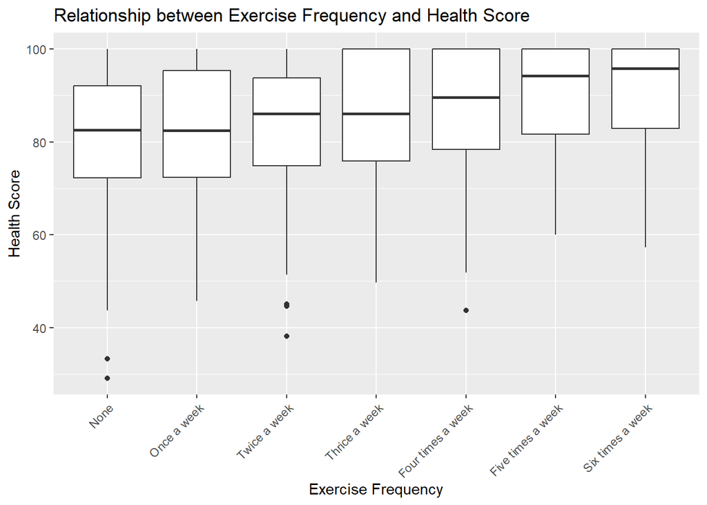

```r
dataset_exercise <- dataset_edit %>%
  mutate(Exercise_Frequency = factor(Exercise_Frequency)) %>%
  ggplot(aes(Exercise_Frequency, Health_Score))+
  geom_boxplot()+
  labs(title = "Relationship between Exercise Frequency and Health Score", x = "Exercise Frequency", y = "Health Score")+
  theme(axis.text.x = element_text(angle = 45, hjust = 1))
dataset_exercise
```

Health Score rises from 0 through to 3-4 sessions, then plateau. Then there is an increase in Health Score in 5-6 sessions weekly. The box plot illustrates that higher Exercise frequency is associated with Higher Health Scores

```r
model <- dataset_edit %>%
  lm(Health_Score ~ Exercise_Frequency + Diet_Quality + BMI + Age + Sleep_Hours
     + Alcohol_Consumption + Smoking_Status, data = .)
summary(model)
```

```
##
## Call:
## lm(formula = Health_Score ~ Exercise_Frequency + Diet_Quality +
##     BMI + Age + Sleep_Hours + Alcohol_Consumption + Smoking_Status,
##     data = .)
##
## Residuals:
##      Min       1Q   Median       3Q      Max
## -25.3916  -3.4025   0.5407   3.8974  14.8998
##
## Coefficients:
##                                     Estimate Std. Error t value Pr(>|t|)
## (Intercept)                         64.29356    1.71901  37.401  < 2e-16 ***
## Exercise_FrequencyOnce a week        1.56486    0.65132   2.403   0.0165 *
## Exercise_FrequencyTwice a week       3.70167    0.63943   5.789  9.5e-09 ***
## Exercise_FrequencyThrice a week      5.34308    0.63638   8.396  < 2e-16 ***
## Exercise_FrequencyFour times a week  7.16609    0.64755  11.067  < 2e-16 ***
## Exercise_FrequencyFive times a week  9.08503    0.65490  13.872  < 2e-16 ***
## Exercise_FrequencySix times a week  10.54624    0.66281  15.911  < 2e-16 ***
## Diet_Quality                         0.60574    0.01187  51.044  < 2e-16 ***
## BMI                                 -1.13331    0.03581 -31.649  < 2e-16 ***
## Age                                 -0.23954    0.01512 -15.840  < 2e-16 ***
## Sleep_Hours                          2.43269    0.11710  20.775  < 2e-16 ***
## Alcohol_Consumption                 -0.98654    0.09026 -10.929  < 2e-16 ***
## Smoking_StatusSmoker                -3.66033    0.35552 -10.296  < 2e-16 ***
## ---
## Signif. codes:  0 '***' 0.001 '**' 0.01 '*' 0.05 '.' 0.1 ' ' 1
##
## Residual standard error: 5.593 on 987 degrees of freedom
## Multiple R-squared:  0.8338, Adjusted R-squared:  0.8317
## F-statistic: 412.5 on 12 and 987 DF,  p-value: < 2.2e-16
```

At an alpha level of 0.05. The model above shows that all predictors are statistically significant (p<0.05), and nearly all being less than 0.01. Increase in Exercise Frequency from None to Once a week increases the Health Score by 1.56, increase to Twice a week increases Health Score by 3.70, with each increase in Exercise Frequency increasing the Health Score. An Increase in Diet Quality by 1 unit increases Health Score by 0.6, An increase in BMI by 1kg/m^2 decreases Health Score by 1.13 on average. Each additional hour of Sleep is associated with an increase in Health Score by 2.43. An increase in Age by 1 year leads to an reduction in Health Score by 0.2. If Alcohol Consumption increases by 1, Health Score will experience a decrease by 0.9. Smokers on average, have a Health Score 3.66 lower than Non-smokers, adjusting for the other variables in the model. Adjusted R-squared of 0.8317 means 83.17% of the Outcome variables can be explained by the seven predictor variables.

```r
best_model <- step(model, direction = "both")
```

```
## Start:  AIC=3455.82
## Health_Score ~ Exercise_Frequency + Diet_Quality + BMI + Age +
##     Sleep_Hours + Alcohol_Consumption + Smoking_Status
##
##                       Df Sum of Sq    RSS    AIC
## <none>                              30871 3455.8
## - Smoking_Status       1      3315  34186 3555.8
## - Alcohol_Consumption  1      3736  34607 3568.1
## - Age                  1      7848  38719 3680.3
## - Exercise_Frequency   6     12752  43623 3789.6
## - Sleep_Hours          1     13499  44370 3816.6
## - BMI                  1     31329  62200 4154.4
## - Diet_Quality         1     81493 112364 4745.7
```

```r
summary(best_model)
```

```
##
## Call:
## lm(formula = Health_Score ~ Exercise_Frequency + Diet_Quality +
##     BMI + Age + Sleep_Hours + Alcohol_Consumption + Smoking_Status,
##     data = .)
##
## Residuals:
##      Min       1Q   Median       3Q      Max
## -25.3916  -3.4025   0.5407   3.8974  14.8998
##
## Coefficients:
##                                     Estimate Std. Error t value Pr(>|t|)
## (Intercept)                         64.29356    1.71901  37.401  < 2e-16 ***
## Exercise_FrequencyOnce a week        1.56486    0.65132   2.403   0.0165 *
## Exercise_FrequencyTwice a week       3.70167    0.63943   5.789  9.5e-09 ***
## Exercise_FrequencyThrice a week      5.34308    0.63638   8.396  < 2e-16 ***
## Exercise_FrequencyFour times a week  7.16609    0.64755  11.067  < 2e-16 ***
## Exercise_FrequencyFive times a week  9.08503    0.65490  13.872  < 2e-16 ***
## Exercise_FrequencySix times a week  10.54624    0.66281  15.911  < 2e-16 ***
## Diet_Quality                         0.60574    0.01187  51.044  < 2e-16 ***
## BMI                                 -1.13331    0.03581 -31.649  < 2e-16 ***
## Age                                 -0.23954    0.01512 -15.840  < 2e-16 ***
## Sleep_Hours                          2.43269    0.11710  20.775  < 2e-16 ***
## Alcohol_Consumption                 -0.98654    0.09026 -10.929  < 2e-16 ***
## Smoking_StatusSmoker                -3.66033    0.35552 -10.296  < 2e-16 ***
## ---
## Signif. codes:  0 '***' 0.001 '**' 0.01 '*' 0.05 '.' 0.1 ' ' 1
##
## Residual standard error: 5.593 on 987 degrees of freedom
## Multiple R-squared:  0.8338, Adjusted R-squared:  0.8317
## F-statistic: 412.5 on 12 and 987 DF,  p-value: < 2.2e-16
```

Stepwise selection (step(), both directions) was run to check whether a simpler model would perform better, it confirmed the full model as the best fit, since dropping any single predictor increased the AIC. So the final model kept all seven predictors.

```r
library(sjPlot)
mod <- tab_model(best_model, transform = NULL, show.aic = TRUE, show.stat = TRUE, p.style = "numeric")
mod
```

|  | Health_Score |  |  |  |
| --- | --- | --- | --- | --- |
| Predictors | Estimates | CI | Statistic | p |
| (Intercept) | 64.29 | 60.92 – 67.67 | 37.40 | **<0.001** |
| Exercise Frequency [Once a week] | 1.56 | 0.29 – 2.84 | 2.40 | **0.016** |
| Exercise Frequency [Twice a week] | 3.70 | 2.45 – 4.96 | 5.79 | **<0.001** |
| Exercise Frequency [Thrice a week] | 5.34 | 4.09 – 6.59 | 8.40 | **<0.001** |
| Exercise Frequency [Four times a week] | 7.17 | 5.90 – 8.44 | 11.07 | **<0.001** |
| Exercise Frequency [Five times a week] | 9.09 | 7.80 – 10.37 | 13.87 | **<0.001** |
| Exercise Frequency [Six times a week] | 10.55 | 9.25 – 11.85 | 15.91 | **<0.001** |
| Diet Quality | 0.61 | 0.58 – 0.63 | 51.04 | **<0.001** |
| BMI | -1.13 | -1.20 – -1.06 | -31.65 | **<0.001** |
| Age | -0.24 | -0.27 – -0.21 | -15.84 | **<0.001** |
| Sleep Hours | 2.43 | 2.20 – 2.66 | 20.77 | **<0.001** |
| Alcohol Consumption | -0.99 | -1.16 – -0.81 | -10.93 | **<0.001** |
| Smoking Status [Smoker] | -3.66 | -4.36 – -2.96 | -10.30 | **<0.001** |
| Observations | 1000 |  |  |  |
| R<sup>2</sup> / R<sup>2</sup> adjusted | 0.834 / 0.832 |  |  |  |
| AIC | 6295.695 |  |  |  |

Package sjPlot, and function tab_model was used to generate a table of the model.

Assumptions

```r
library(car)
```

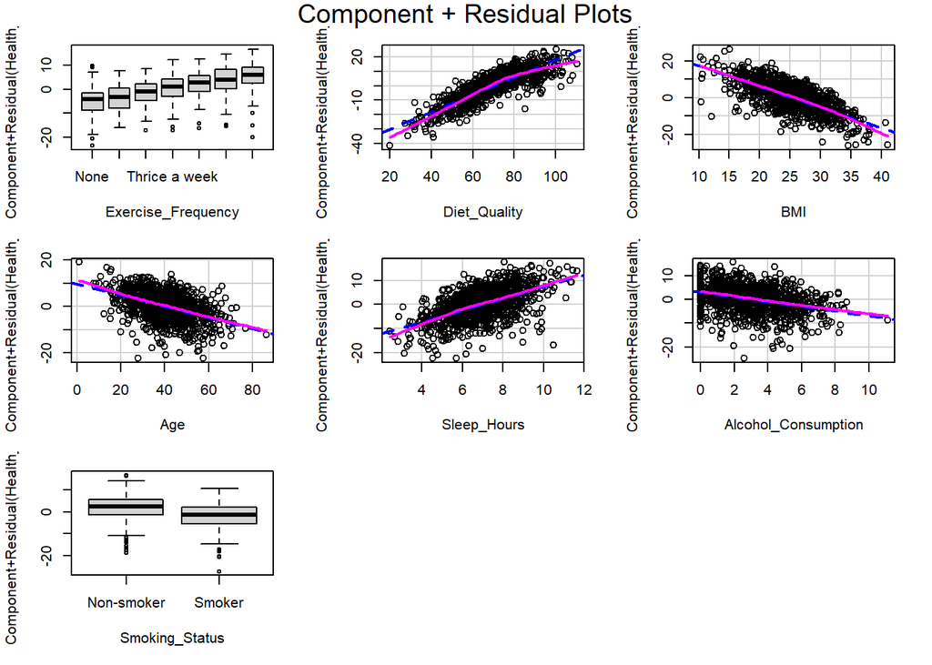

```r
crPlots(best_model)
```

crPlots from the car package was used to test the Component + Residual plots. This is usually done to check whether each predictor has a linear relationship with the outcome variable, after accounting for other predictors in the model. We look out for a pink and a blue line. Diet quality: There is a slight curve, the pink line follows the blue line which shows linearity BMI: Pink and blue line are close with a downward slope, shows linearity. Age: Decent match between the lines, linear relationship Sleep Hours: Upward trend, Pink line curves slightly, still linear Alcohol Consumption: Shows a downward trend, Pink and blue lines show linearity Exercise Frequency: Box plots show component + residual roughly increasing with increase in exercise frequency Smoking Status: Box plot show a decrease from Non-smoker to Smoker

Overall: All predictors look linear. The assumption of linearity for this regression model is met

```r
library(lmtest)
dwtest(best_model)
```

```
##
##  Durbin-Watson test
##
## data:  best_model
## DW = 1.9385, p-value = 0.1652
## alternative hypothesis: true autocorrelation is greater than 0
```

The Durbin-Watson test was performed to check for autocorrelation in the residuals. DW: 1.9385 (very close to 2, therefore, there is little to no autocorrelation) p-value: 0.1652 (greater then 0.05, therefore, we fail to reject the null hypothesis) There is no statistically significant evidence of autocorrelation in the residuals.

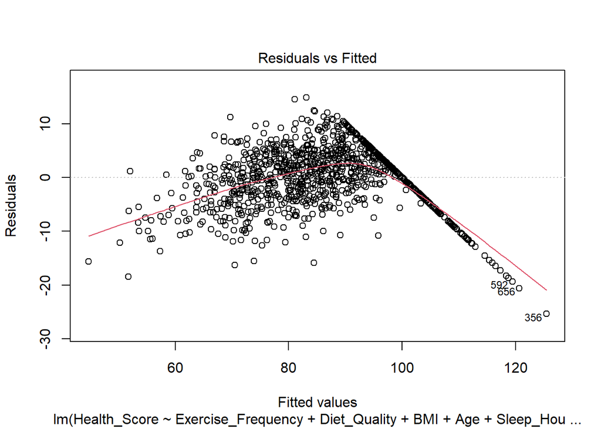

```r
plot(best_model, which = 1)
```

A Residuals vs Fitted plot was done to check for Linearity and Homoscedasticity The plot shows that the points form a pattern and are not randomly scattered around the horizontal line. There is a curve on the red line, it rises gently from about 60 to 90, then bends sharply downward after 90 - 100, which signals nonlinearity. Around fitted values 90-120, there is a tight, sharp bend of points which all fall in an almost perfectly diagonal straight line. This shows that there is a cap on the outcome variable (Explained by the maximum health score, which is 100). 356, 592 and 656 are outliers. Spread of residuals is not fully constant across fitted values( it is tighter on the right, wider in the middle), this is a sign of heteroscedasticity Conclusion, plot shows nonlinearity and heteroscedaticity.

```r
bptest(best_model)
```

```
##
##  studentized Breusch-Pagan test
##
## data:  best_model
## BP = 31.926, df = 12, p-value = 0.001421
```

Breusch-Pagan test was done, this is to measure how much the residual’s variance depeds on the fitted values p = 0.0014 (less than 0.05, hence, the null hypothesis is rejected) Conclusion: Confirms the heteroscedasticity seen in the residuals vs fitted plot.

```r
shapiro.test(residuals(best_model))
```

```
##
##  Shapiro-Wilk normality test
##
## data:  residuals(best_model)
## W = 0.98281, p-value = 1.786e-09
```

The Shapiro-Wilk normality test was done to check if the model’s residuals are normally distributed p-value is far below 0.05, the null hypothesis is rejected. Therefore, the residuals are not normally distributed.

```r
vif(best_model)
```

```
##                         GVIF Df GVIF^(1/(2*Df))
## Exercise_Frequency  1.040736  6        1.003333
## Diet_Quality        1.008290  1        1.004137
## BMI                 1.018687  1        1.009300
## Age                 1.008492  1        1.004237
## Sleep_Hours         1.008154  1        1.004069
## Alcohol_Consumption 1.006446  1        1.003218
## Smoking_Status      1.010274  1        1.005124
```

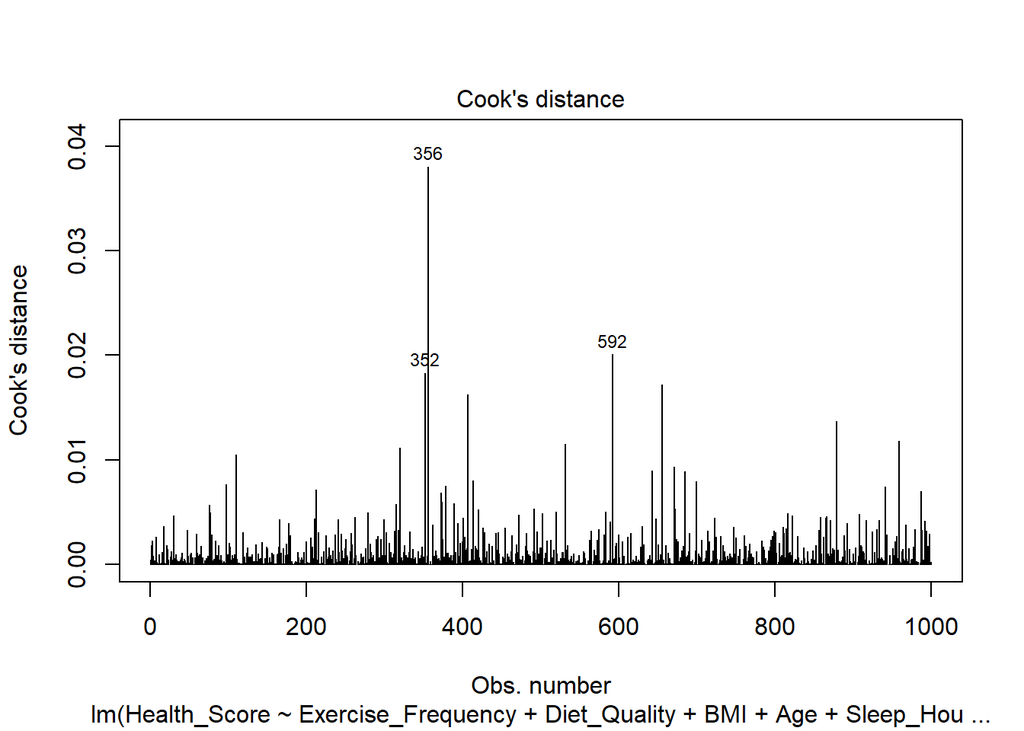

```r
plot(best_model, which = 4)
```

A Cook’s Distance plot was done, to measure the influence each individual data point has on the regression model’s fitted coefficients. Using the treshold of 4/n(n is the number of observations), therefore, any point exceeding 0.004 warrant further investigation, since they may reflect extreme or unusual combinations of predictor values. Point 356 and 592 which showed up as outliers in the residual vs fitted plot also stands out, in addition to point 352

Limitations Some of the limitations include: 1. Data is synthetic 2. The health score is capped at 100, which is likely the cause of the nonlinearity and heteroscedaticity noted in the assumptions 3. Assumption violations; Nonlinearity in the residuals vs fitted plot, Heteroscedasticity(confirmed via Breusch-Pagan), Non-normal residuals (confirmed via Shapiro-Wilk) 4. Influential points were not addressed, points such as 356, 592 and 352 5. The cross-scetional nature of the data makes establishing causation difficult.